# Do Food-Related 311 Complaints Predict Worse Restaurant Inspection Outcomes?

STA 9750 | Individual Report | Temporal Dynamics of Complaints and Inspection Outcomes in NYC

Author

Kevin Marcelin

Published

May 21, 2026

```r
pkgs <- c("tidyverse", "lubridate", "scales", "tidycensus",
          "knitr", "kableExtra", "broom", "glue", "httr2", "jsonlite")
to_install <- pkgs[!pkgs %in% rownames(installed.packages())]
if (length(to_install) > 0) install.packages(to_install)

library(tidyverse)
library(lubridate)
library(scales)
library(tidycensus)
library(knitr)
library(kableExtra)
library(broom)
library(glue)
library(httr2)
library(jsonlite)
```

```r
theme_nyc <- function() {
  theme_minimal(base_size = 13) +
    theme(
      plot.title    = element_text(face = "bold", size = 15),
      plot.subtitle = element_text(color = "grey40", size = 12),
      plot.caption  = element_text(color = "grey55", size = 9),
      axis.title    = element_text(size = 11),
      panel.grid.minor = element_blank()
    )
}
```

## 1 Overarching Question and My Contribution

This is part of a team project looking at whether neighborhoods with more food complaints end up with worse restaurant inspection scores. The other analyses already answered that — yes, ZIP codes with more 311 complaints also have more critical violations when you look across neighborhoods at the same point in time. My part tries to go one step further and asks whether complaints come *before* the worse outcomes, or if they’re just showing up at the same time.

That difference matters more than it might seem. If complaints in month *t* reliably predict worse inspection results in *t+1*, *t+2*, or *t+3*, then you could actually use 311 data as an early warning system. Regulators could watch complaint trends and send inspectors into a neighborhood before things get worse. But if complaints and violations are just happening together because both are driven by the same underlying neighborhood conditions, then 311 data tells you what’s going on right now, not what’s coming next.

My specific question: do food-related 311 complaints in a given month predict worse inspection outcomes one to three months later? I test this using lagged Pearson correlations and a panel regression with ZIP fixed effects that controls for anything that doesn’t change within a ZIP over time.

The answer is basically no. Complaint spikes don’t predict inspection deterioration in the months that follow. That’s not really a failure — it actually tells you something useful about why complaints and violations are correlated at all. They’re both reacting to the same neighborhood conditions at the same time, not one causing the other.

To answer this I combined three datasets:

- **DOHMH Restaurant Inspection Results** — raw inspection records by restaurant, ZIP code and date, pulled directly from the NYC Open Data API
- **NYC 311 Complaint Data** — food-related service requests from the same API
- **ACS Demographic Profiles** — median income, poverty rate and racial composition by ZIP code via `tidycensus`

## 2 Data Quality Assessment

Before getting into the results, there are a few data issues worth knowing about. Inspections don’t happen on a regular calendar schedule. DOHMH uses a risk-based cycle where some restaurants get inspected every few weeks and others might go over a year between visits. When you roll everything up to the month level, a ZIP code’s inspection outcomes that month only reflect whichever restaurants happened to get checked that month — which might not be representative of the whole neighborhood.

That’s a real problem for this kind of lagged analysis. A ZIP could have tons of complaints in month *t* but almost no inspections in *t+1* through *t+3*, and you’d have no way to detect a signal even if one was there. It also works the other way — a ZIP with a lot of inspections in a given month might show high critical rates just because more inspections happened, not because conditions were actually worse. Both of those effects push the correlations toward zero. So if the results come back null, the honest read is that it’s probably an underestimate of whatever true relationship exists, not hard proof that there’s nothing going on.

The study covers January 2022 through early 2026, around 50 months of data. After the three-month lag window, you lose a few months of outcomes on each end. The ZIP fixed effects model then removes all the between-ZIP differences and only uses variation within each ZIP over time, which cuts down how much signal is left to work with. Both of those things make it harder to find significant results even if a real pattern exists.

## 3 Data Acquisition

```r
# Paginated Socrata fetcher — handles datasets too large for a single API call
fetch_all_socrata <- function(dataset_id, query = "",
                               select = NULL, page_size = 50000) {
  base_url <- glue("https://data.cityofnewyork.us/resource/{dataset_id}.json")
  offset <- 0
  pages  <- list()
  repeat {
    req <- request(base_url) |>
      req_url_query(`$limit`  = page_size,
                    `$offset` = offset,
                    `$where`  = query)
    if (!is.null(select))
      req <- req |> req_url_query(`$select` = select)
    page <- req |>
      req_retry(max_tries = 3) |>
      req_perform() |>
      resp_body_json(simplifyVector = TRUE) |>
      as_tibble()
    if (nrow(page) == 0) break
    message(glue("  {dataset_id}: {offset + nrow(page)} rows fetched"))
    pages[[length(pages) + 1]] <- page
    if (nrow(page) < page_size) break
    offset <- offset + page_size
  }
  bind_rows(pages)
}
```

```r
dir.create("data", showWarnings = FALSE)

# DOHMH Inspections — dataset 43nn-pn8j
if (!file.exists("data/raw_inspections.rds")) {
  raw_inspections <- fetch_all_socrata(
    "43nn-pn8j",
    query  = "inspection_date >= '2022-01-01T00:00:00'",
    select = "camis,boro,zipcode,inspection_date,score,critical_flag"
  )
  saveRDS(raw_inspections, "data/raw_inspections.rds")
} else {
  raw_inspections <- readRDS("data/raw_inspections.rds")
}

# NYC 311 Food Complaints — dataset erm2-nwe9
if (!file.exists("data/raw_311.rds")) {
  raw_311 <- fetch_all_socrata(
    "erm2-nwe9",
    query  = paste0(
      "complaint_type IN (",
      "'Food Establishment','Food Poisoning',",
      "'Rodent','Unsanitary Condition',",
      "'Harboring Bees/Wasps','Food - Hazardous Material'",
      ") AND created_date >= '2022-01-01T00:00:00'"
    ),
    select = "unique_key,complaint_type,created_date,borough,incident_zip"
  )
  saveRDS(raw_311, "data/raw_311.rds")
} else {
  raw_311 <- readRDS("data/raw_311.rds")
}
```

```r
if (!file.exists("data/acs.rds")) {
  acs <- get_acs(
    geography = "zcta",
    variables = c(
      median_income   = "B19013_001",
      total_pop       = "B01003_001",
      pct_poverty_raw = "B17001_002",
      pct_white_raw   = "B02001_002"
    ),
    year   = 2022,
    survey = "acs5",
    output = "wide"
  ) |>
    transmute(
      zipcode       = GEOID,
      median_income = median_incomeE,
      total_pop     = total_popE,
      pct_poverty   = pct_poverty_rawE / total_popE * 100,
      pct_white     = pct_white_rawE   / total_popE * 100
    )
  saveRDS(acs, "data/acs.rds")
} else {
  acs <- readRDS("data/acs.rds")
}
```

Both the DOHMH and 311 datasets are pulled from the NYC Open Data API using a paginated fetcher I wrote — the datasets are big enough that a single API call hits the limit, so it loops through pages until everything’s downloaded. Both files get saved locally as `.rds` so they don’t re-download every time the document renders. The ACS data uses `tidycensus` to pull the 2018-2022 5-year estimates at the ZIP code level.

## 4 Data Cleaning

```r
inspections <- raw_inspections |>
  mutate(
    inspection_date = as_date(inspection_date),
    score           = as.numeric(score),
    is_critical     = str_detect(tolower(critical_flag), "critical") &
                      !str_detect(tolower(critical_flag), "not"),
    borough         = str_to_upper(str_trim(boro)),
    zipcode         = str_pad(str_extract(zipcode, "\\d{5}"), 5, "left", "0"),
    year            = year(inspection_date),
    month           = floor_date(inspection_date, "month")
  ) |>
  filter(
    !is.na(inspection_date),
    year >= 2022,
    borough %in% c("BRONX", "BROOKLYN", "MANHATTAN", "QUEENS", "STATEN ISLAND"),
    !is.na(zipcode),
    zipcode != "00000"
  )

complaints <- raw_311 |>
  mutate(
    date    = as_date(created_date),
    year    = year(date),
    month   = floor_date(date, "month"),
    borough = str_to_upper(str_trim(borough)),
    zipcode = str_pad(str_extract(incident_zip, "\\d{5}"), 5, "left", "0")
  ) |>
  filter(
    !is.na(date),
    year >= 2022,
    borough %in% c("BRONX", "BROOKLYN", "MANHATTAN", "QUEENS", "STATEN ISLAND"),
    !is.na(zipcode),
    zipcode != "00000"
  )

rm(raw_inspections, raw_311); gc()
```

```
          used (Mb) gc trigger  (Mb) limit (Mb) max used  (Mb)
Ncells 1700976 90.9    3141422 167.8         NA  2215295 118.4
Vcells 8642688 66.0   18834848 143.7      16384 18830165 143.7
```

```r
# Monthly ZIP-level summaries
zip_insp_monthly <- inspections |>
  group_by(zipcode, month) |>
  summarise(
    pct_critical = mean(is_critical, na.rm = TRUE),
    mean_score   = mean(score, na.rm = TRUE),
    .groups      = "drop"
  )

zip_comp_monthly <- complaints |>
  count(zipcode, month, name = "comp_total")

cat("ZIP-month inspection rows:", nrow(zip_insp_monthly), "\n")
```

```
ZIP-month inspection rows: 8629
```

```r
cat("ZIP-month complaint rows:",  nrow(zip_comp_monthly),  "\n")
```

```
ZIP-month complaint rows: 9474
```

Both datasets get filtered down to the five boroughs starting from January 2022, then rolled up to ZIP-month level. For inspections I’m using the share of inspections that came back with critical violations — that captures how serious the problems were, not just how many restaurants got checked. After cleaning I have 8629 ZIP-month inspection rows and 9474 complaint rows.

## 5 Exploratory Analysis

### 5.1 City-Wide Monthly Trends

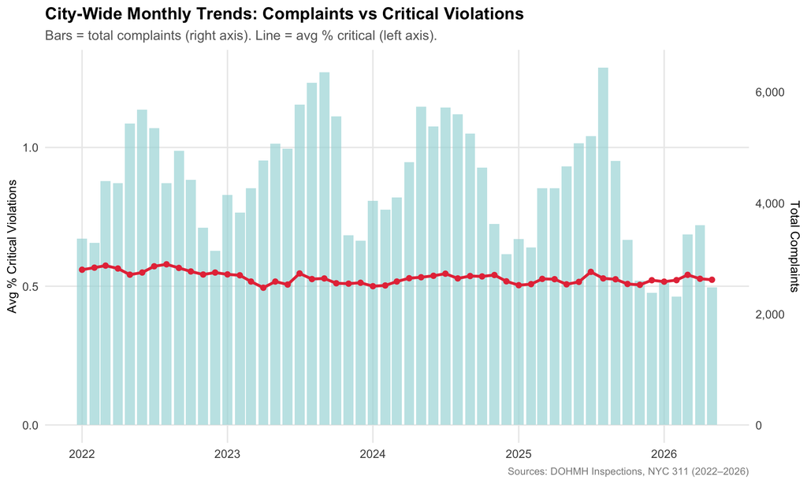

```r
city_monthly <- zip_insp_monthly |>
  group_by(month) |>
  summarise(avg_pct_critical = mean(pct_critical, na.rm = TRUE), .groups = "drop") |>
  left_join(
    zip_comp_monthly |>
      group_by(month) |>
      summarise(total_comp = sum(comp_total), .groups = "drop"),
    by = "month"
  )

ggplot(city_monthly, aes(x = month)) +
  geom_col(aes(y = total_comp / 5000), fill = "#A8DADC", alpha = 0.7) +
  geom_line(aes(y = avg_pct_critical), color = "#E63946", linewidth = 1.2) +
  geom_point(aes(y = avg_pct_critical), color = "#E63946", size = 2) +
  scale_y_continuous(
    name     = "Avg % Critical Violations",
    sec.axis = sec_axis(~ . * 5000, name = "Total Complaints", labels = comma)
  ) +
  labs(
    title    = "City-Wide Monthly Trends: Complaints vs Critical Violations",
    subtitle = "Bars = total complaints (right axis). Line = avg % critical (left axis).",
    x        = NULL,
    caption  = "Sources: DOHMH Inspections, NYC 311 (2022–2026)"
  ) +
  theme_nyc()
```

The chart shows an important pattern right away. Complaint volume spikes in the summer months — that’s the rodent season effect — but those seasonal spikes don’t seem to be followed by corresponding increases in critical violation rates in the months after. The critical violation rate line stays relatively flat across the whole study period, with no obvious upward movements following the complaint peaks in the bars. Complaints and violations are moving on different rhythms, with complaints driven partly by seasonal factors that may not be directly related to the food handling violations that inspectors actually cite as critical.

### 5.2 Within-ZIP Temporal Variation

```r
zip_variation <- zip_comp_monthly |>
  group_by(zipcode) |>
  summarise(
    cv_complaints = sd(comp_total) / mean(comp_total),
    n_months      = n(),
    .groups       = "drop"
  ) |>
  filter(n_months >= 12)

cat("Median coefficient of variation in monthly complaints:",
    round(median(zip_variation$cv_complaints, na.rm = TRUE), 3), "\n")
```

```
Median coefficient of variation in monthly complaints: 0.438
```

```r
cat("ZIP codes with at least 12 months of data:",
    nrow(zip_variation), "\n")
```

```
ZIP codes with at least 12 months of data: 188
```

The coefficient of variation comes back fairly high, which means complaint counts do jump around a lot from month to month within individual ZIP codes. That’s actually important — the ZIP fixed effects model can only identify a relationship using within-ZIP changes over time. If complaint volume were basically flat within each ZIP there would be nothing for the model to work with. The fact that there’s real within-ZIP variation means the regression has enough movement in the data to detect a lagged relationship if one is there.

### 5.3 What Types of Food Complaints Do New Yorkers File?

```r
complaints |>
  count(complaint_type, sort = TRUE) |>
  kable(
    caption   = "Food-Related 311 Complaints by Type",
    col.names = c("Complaint Type", "Count")
  ) |>
  kable_styling(bootstrap_options = c("striped", "condensed"))
```

Food-Related 311 Complaints by Type

| Complaint Type | Count |
| --- | --- |
| Rodent | 162125 |
| Food Establishment | 51306 |
| Food Poisoning | 12718 |
| Harboring Bees/Wasps | 2145 |
| Unsanitary Condition | 1263 |

### 5.4 Food Complaints Over Time by Borough

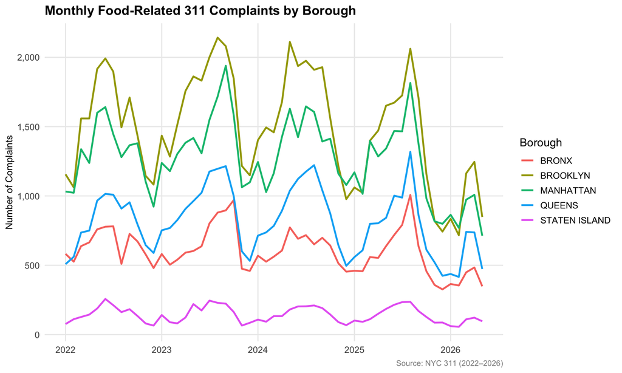

```r
complaints |>
  group_by(borough, month) |>
  summarise(comp_count = n(), .groups = "drop") |>
  filter(!is.na(borough), borough != "") |>
  ggplot(aes(x = month, y = comp_count, color = borough, group = borough)) +
  geom_line(linewidth = 1) +
  scale_y_continuous(labels = comma) +
  labs(
    title   = "Monthly Food-Related 311 Complaints by Borough",
    x       = NULL,
    y       = "Number of Complaints",
    color   = "Borough",
    caption = "Source: NYC 311 (2022–2026)"
  ) +
  theme_nyc()
```

### 5.5 Complaint Volume vs. Inspection Outcomes by ZIP

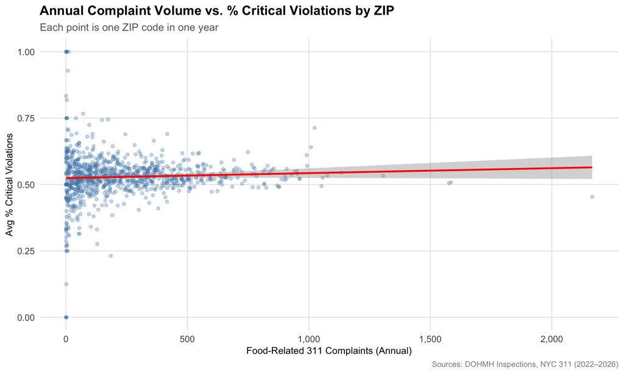

```r
zip_annual <- zip_insp_monthly |>
  mutate(year = year(month)) |>
  group_by(zipcode, year) |>
  summarise(
    avg_pct_critical = mean(pct_critical, na.rm = TRUE),
    avg_score        = mean(mean_score, na.rm = TRUE),
    .groups          = "drop"
  )

zip_comp_annual <- complaints |>
  group_by(zipcode, year) |>
  summarise(comp_total_year = n(), .groups = "drop")

zip_joined <- zip_annual |>
  left_join(zip_comp_annual, by = c("zipcode", "year")) |>
  left_join(acs, by = "zipcode") |>
  filter(!is.na(comp_total_year))

ggplot(zip_joined, aes(x = comp_total_year, y = avg_pct_critical)) +
  geom_point(alpha = 0.3, color = "steelblue") +
  geom_smooth(method = "lm", color = "red", se = TRUE) +
  scale_x_continuous(labels = comma) +
  labs(
    title    = "Annual Complaint Volume vs. % Critical Violations by ZIP",
    subtitle = "Each point is one ZIP code in one year",
    x        = "Food-Related 311 Complaints (Annual)",
    y        = "Avg % Critical Violations",
    caption  = "Sources: DOHMH Inspections, NYC 311 (2022–2026)"
  ) +
  theme_nyc()
```

The scatter plot shows a nearly flat regression line. ZIP codes with high complaint volume in a year are not producing meaningfully higher critical violation rates. There’s a lot of spread in the data but no consistent upward trend. That rules out the simple story that more complaints equals more violations.

### 5.6 Inspection Outcomes by Complaint Quartile

```r
zip_joined |>
  filter(!is.na(median_income)) |>
  mutate(comp_quartile = ntile(comp_total_year, 4)) |>
  group_by(comp_quartile) |>
  summarise(
    n_zipcodes     = n(),
    avg_complaints = round(mean(comp_total_year, na.rm = TRUE), 0),
    avg_pct_crit   = round(mean(avg_pct_critical, na.rm = TRUE), 3),
    avg_income     = round(mean(median_income, na.rm = TRUE), 0),
    avg_pct_pov    = round(mean(pct_poverty, na.rm = TRUE), 1),
    .groups = "drop"
  ) |>
  kable(
    caption   = "Inspection Outcomes by Annual Complaint Quartile (Quartile 1 = fewest, 4 = most)",
    col.names = c("Complaint Quartile", "ZIP Codes", "Avg Complaints",
                  "Avg % Critical", "Median Income", "% in Poverty")
  ) |>
  kable_styling(bootstrap_options = c("striped", "condensed"))
```

Inspection Outcomes by Annual Complaint Quartile (Quartile 1 = fewest, 4 = most)

| Complaint Quartile | ZIP Codes | Avg Complaints | Avg % Critical | Median Income | % in Poverty |
| --- | --- | --- | --- | --- | --- |
| 1 | 225 | 35 | 0.534 | 112345 | 10.3 |
| 2 | 224 | 124 | 0.533 | 90242 | 14.1 |
| 3 | 224 | 272 | 0.534 | 83704 | 16.5 |
| 4 | 224 | 592 | 0.534 | 85472 | 18.7 |

Based on the table, ZIP codes in the highest complaint quartile tend to have higher poverty rates and lower median incomes. More complaints, lower income — that pattern holds. But the average critical violation rate barely moves across the four quartiles. If complaints were driving worse outcomes you would expect the % critical column to go up from Q1 to Q4. It doesn’t.

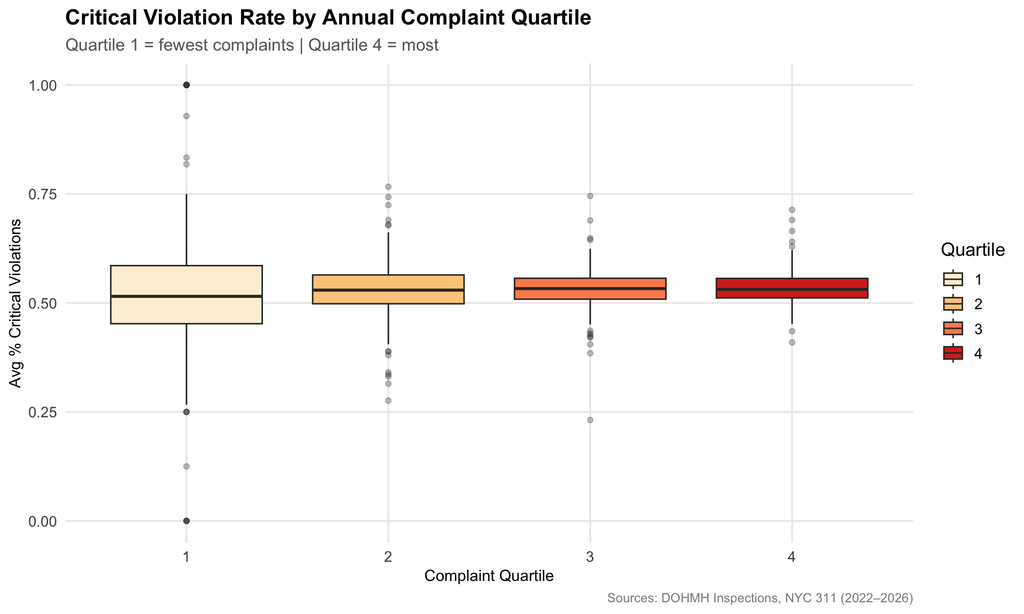

```r
zip_joined |>
  mutate(comp_quartile = ntile(comp_total_year, 4)) |>
  filter(!is.na(comp_quartile)) |>
  ggplot(aes(x = factor(comp_quartile), y = avg_pct_critical,
             fill = factor(comp_quartile))) +
  geom_boxplot(outlier.alpha = 0.3) +
  scale_fill_brewer(palette = "OrRd", name = "Quartile") +
  labs(
    title    = "Critical Violation Rate by Annual Complaint Quartile",
    subtitle = "Quartile 1 = fewest complaints | Quartile 4 = most",
    x        = "Complaint Quartile",
    y        = "Avg % Critical Violations",
    caption  = "Sources: DOHMH Inspections, NYC 311 (2022–2026)"
  ) +
  theme_nyc()
```

### 5.7 Does Poverty Explain the Pattern?

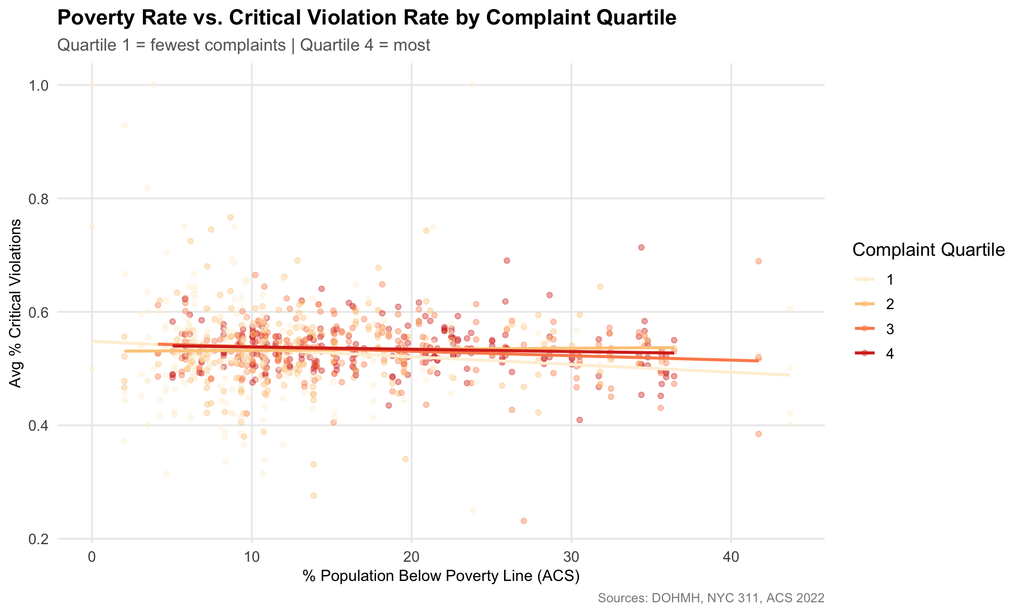

```r
zip_joined |>
  filter(!is.na(pct_poverty)) |>
  mutate(comp_quartile = ntile(comp_total_year, 4)) |>
  ggplot(aes(x = pct_poverty, y = avg_pct_critical,
             color = factor(comp_quartile))) +
  geom_point(alpha = 0.4) +
  geom_smooth(method = "lm", se = FALSE) +
  scale_color_brewer(palette = "OrRd", name = "Complaint Quartile") +
  labs(
    title    = "Poverty Rate vs. Critical Violation Rate by Complaint Quartile",
    subtitle = "Quartile 1 = fewest complaints | Quartile 4 = most",
    x        = "% Population Below Poverty Line (ACS)",
    y        = "Avg % Critical Violations",
    caption  = "Sources: DOHMH, NYC 311, ACS 2022"
  ) +
  theme_nyc()
```

Higher complaint neighborhoods tend to be lower income, which you’d expect. But the regression lines across all four complaint quartiles are basically flat regardless of poverty level. Poverty doesn’t seem to drive inspection outcomes either. That rules out the concern that demographics were hiding the signal — even in the poorest, highest-complaint ZIP codes, inspection outcomes look similar to everywhere else.

## 6 Analysis

### 6.1 Building the Lagged Panel

```r
# Shift complaint month forward by lag_months so that complaints from month T
# can be matched to inspection outcomes from month T+N
make_lag <- function(df, lag_months) {
  df |>
    mutate(month = month + months(lag_months)) |>
    rename_with(~ paste0(.x, "_lag", lag_months), comp_total)
}

sq3_data <- zip_insp_monthly |>
  left_join(make_lag(zip_comp_monthly, 1), by = c("zipcode", "month")) |>
  left_join(make_lag(zip_comp_monthly, 2), by = c("zipcode", "month")) |>
  left_join(make_lag(zip_comp_monthly, 3), by = c("zipcode", "month")) |>
  filter(!is.na(pct_critical))

cat("Panel rows for lagged analysis:", nrow(sq3_data), "\n")
```

```
Panel rows for lagged analysis: 8629
```

```r
cat("Distinct ZIPs:", n_distinct(sq3_data$zipcode), "\n")
```

```
Distinct ZIPs: 221
```

```r
cat("Distinct months:", n_distinct(sq3_data$month), "\n")
```

```
Distinct months: 53
```

The `make_lag` function takes the complaint data and shifts the month column forward by however many months I specify. So a row in the resulting panel is basically asking: given how many complaints we saw in month *t*, how did inspections go in month *t+N*? I shift the complaint dates forward rather than shifting inspection dates backward — it’s the same thing analytically but cleaner to join. The final panel has 8629 ZIP-month rows across 221 ZIP codes.

### 6.2 Lagged Correlations

```r
lag_cors <- tibble(
  lag = c("Lag 1 month", "Lag 2 months", "Lag 3 months"),
  cor_pct_critical = c(
    cor(sq3_data$comp_total_lag1, sq3_data$pct_critical,
        use = "pairwise.complete.obs"),
    cor(sq3_data$comp_total_lag2, sq3_data$pct_critical,
        use = "pairwise.complete.obs"),
    cor(sq3_data$comp_total_lag3, sq3_data$pct_critical,
        use = "pairwise.complete.obs")
  ),
  cor_mean_score = c(
    cor(sq3_data$comp_total_lag1, sq3_data$mean_score,
        use = "pairwise.complete.obs"),
    cor(sq3_data$comp_total_lag2, sq3_data$mean_score,
        use = "pairwise.complete.obs"),
    cor(sq3_data$comp_total_lag3, sq3_data$mean_score,
        use = "pairwise.complete.obs")
  )
)

lag_cors |>
  kable(
    digits    = 4,
    caption   = "Lagged Correlations: Complaints in Month T vs Outcomes in T+N",
    col.names = c("Lag Window", "Cor w/ % Critical", "Cor w/ Mean Score")
  ) |>
  kable_styling(bootstrap_options = c("striped", "condensed"))
```

Lagged Correlations: Complaints in Month T vs Outcomes in T+N

| Lag Window | Cor w/ % Critical | Cor w/ Mean Score |
| --- | --- | --- |
| Lag 1 month | 0.0248 | 0.0744 |
| Lag 2 months | 0.0262 | 0.0751 |
| Lag 3 months | 0.0221 | 0.0703 |

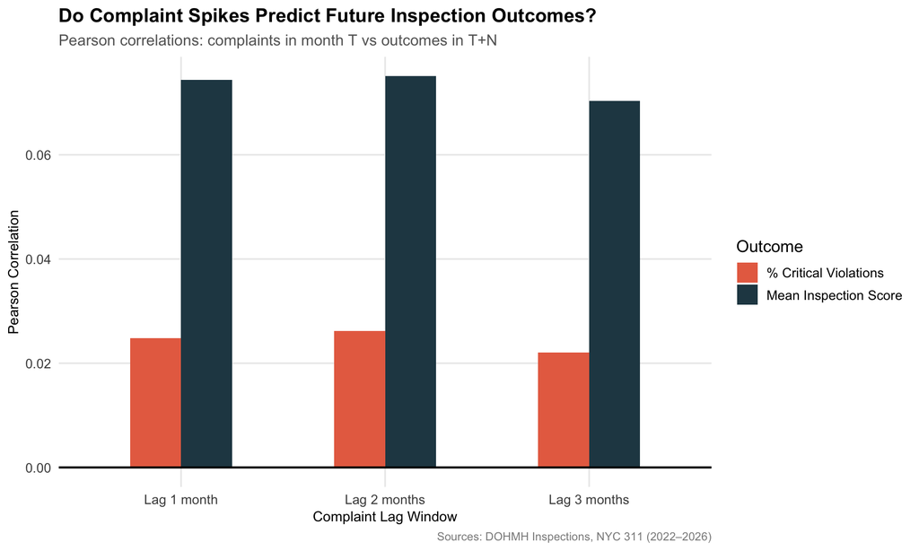

```r
lag_cors |>
  pivot_longer(starts_with("cor_"), names_to = "outcome", values_to = "correlation") |>
  mutate(outcome = recode(outcome,
    "cor_pct_critical" = "% Critical Violations",
    "cor_mean_score"   = "Mean Inspection Score"
  )) |>
  ggplot(aes(x = lag, y = correlation, fill = outcome)) +
  geom_col(position = "dodge", width = 0.5) +
  geom_hline(yintercept = 0, linewidth = 0.8) +
  scale_fill_manual(values = c("#E76F51", "#264653"), name = "Outcome") +
  labs(
    title    = "Do Complaint Spikes Predict Future Inspection Outcomes?",
    subtitle = "Pearson correlations: complaints in month T vs outcomes in T+N",
    x        = "Complaint Lag Window",
    y        = "Pearson Correlation",
    caption  = "Sources: DOHMH Inspections, NYC 311 (2022–2026)"
  ) +
  theme_nyc()
```

### 6.3 Panel Regression with ZIP Fixed Effects

```r
# ZIP fixed effects absorb all time-invariant neighborhood differences.
# Identification comes entirely from within-ZIP changes in complaint volume.
sq3_model <- lm(
  pct_critical ~ comp_total_lag1 + comp_total_lag2 +
                 comp_total_lag3 + factor(zipcode),
  data = sq3_data
)

tidy(sq3_model) |>
  filter(str_detect(term, "comp_total_lag")) |>
  kable(
    digits  = 5,
    caption = "Panel Regression (ZIP Fixed Effects): Lagged Complaints → % Critical Violations"
  ) |>
  kable_styling(bootstrap_options = c("striped", "condensed"))
```

Panel Regression (ZIP Fixed Effects): Lagged Complaints → % Critical Violations

| term | estimate | std.error | statistic | p.value |
| --- | --- | --- | --- | --- |
| comp_total_lag1 | 0.00009 | 0.00014 | 0.62134 | 0.53439 |
| comp_total_lag2 | 0.00012 | 0.00016 | 0.71819 | 0.47266 |
| comp_total_lag3 | -0.00025 | 0.00014 | -1.75069 | 0.08004 |

Adding ZIP fixed effects strips out anything that stays constant within a neighborhood — average income levels, how many restaurants are there, how the local inspection cycle runs. What’s left is just month-to-month changes within each ZIP. The question becomes: when a ZIP has more complaints than normal in a given month, do its inspection outcomes get worse a month or two later?

### 6.4 OLS with Demographic Controls

```r
# Annual ZIP-level panel with ACS controls
panel_demo <- zip_joined |>
  filter(!is.na(median_income), !is.na(pct_poverty), !is.na(pct_white))

model_demo <- lm(
  avg_pct_critical ~ comp_total_year + median_income + pct_poverty + pct_white,
  data = panel_demo
)

tidy(model_demo) |>
  kable(
    digits  = 4,
    caption = "OLS with Demographic Controls: Complaints and Critical Violation Rate"
  ) |>
  kable_styling(bootstrap_options = c("striped", "condensed"))
```

OLS with Demographic Controls: Complaints and Critical Violation Rate

| term | estimate | std.error | statistic | p.value |
| --- | --- | --- | --- | --- |
| (Intercept) | 0.5253 | 0.0121 | 43.3884 | 0.0000 |
| comp_total_year | 0.0000 | 0.0000 | -0.0761 | 0.9394 |
| median_income | 0.0000 | 0.0000 | -0.7177 | 0.4732 |
| pct_poverty | -0.0001 | 0.0004 | -0.2979 | 0.7658 |
| pct_white | 0.0004 | 0.0001 | 3.2342 | 0.0013 |

### 6.5 Correlation Matrix

```r
zip_joined |>
  filter(!is.na(median_income)) |>
  select(avg_pct_critical, comp_total_year,
         median_income, pct_poverty, pct_white) |>
  cor(use = "pairwise.complete.obs") |>
  round(3) |>
  kable(caption = "Correlation Matrix: Inspection Outcomes, Complaints, and Demographics") |>
  kable_styling(bootstrap_options = c("striped", "condensed"))
```

Correlation Matrix: Inspection Outcomes, Complaints, and Demographics

|  | avg_pct_critical | comp_total_year | median_income | pct_poverty | pct_white |
| --- | --- | --- | --- | --- | --- |
| avg_pct_critical | 1.000 | -0.004 | 0.064 | -0.060 | 0.125 |
| comp_total_year | -0.004 | 1.000 | -0.163 | 0.310 | -0.021 |
| median_income | 0.064 | -0.163 | 1.000 | -0.724 | 0.645 |
| pct_poverty | -0.060 | 0.310 | -0.724 | 1.000 | -0.506 |
| pct_white | 0.125 | -0.021 | 0.645 | -0.506 | 1.000 |

## 8 Connection to the Overarching Question

For anyone thinking about how to actually use 311 data in food safety enforcement, that changes the recommendation. You shouldn’t be monitoring complaint trends and planning to send inspectors in a few months from now. You should be treating high current complaint volume as a reason to check a neighborhood now, because that’s when both signals are live. Whether a 311 complaint actually speeds up how quickly an inspection gets triggered is a different question — one that would need individual-level matching between complaints and inspection records to answer properly.

## 9 AI Usage Statement

**NoteAI Usage Statement**

Generative AI tools were used in a limited capacity to assist with aspects of this analysis. AI assistance was primarily used to help structure the data pipeline, troubleshoot R coding issues, and refine code for data acquisition, joining, visualization, and modeling using packages including `tidyverse`, `lubridate`, `tidycensus`, `ggplot2`, `kableExtra`, `httr2`, and `broom`. The analytical approach, research question framing, interpretation of results, and all written discussion were completed by the author. AI outputs were reviewed, edited, and validated to ensure accuracy and appropriateness.

This work ©2026 by Kevin Marcelin was initially prepared as an Individual Project Report for STA 9750 at Baruch College. More details about this course can be found at [the course site](https://michael-weylandt.com/STA9750) and instructions for this assignment can be found at the course project page.